# Risk Factor Analysis

## Outcome Variable

**Outcome Variable:** stunted

## Predictor Variables

**Intervention Variable:** meducyrs

**Adjustment Set:**

unadjusted

## Stratifying Variables

The analysis was stratified on these variable(s):

- agecat
- studyid
- country

## Data Summary

| agecat | studyid | country | meducyrs | stunted | n_cell | n |
| --- | --- | --- | --- | --- | --- | --- |
| Birth | ki0047075b-MAL-ED | BANGLADESH | Low | 0 | 51 | 207 |
| Birth | ki0047075b-MAL-ED | BANGLADESH | Low | 1 | 17 | 207 |
| Birth | ki0047075b-MAL-ED | BANGLADESH | Medium | 0 | 54 | 207 |
| Birth | ki0047075b-MAL-ED | BANGLADESH | Medium | 1 | 10 | 207 |
| Birth | ki0047075b-MAL-ED | BANGLADESH | High | 0 | 66 | 207 |
| Birth | ki0047075b-MAL-ED | BANGLADESH | High | 1 | 9 | 207 |
| Birth | ki0047075b-MAL-ED | BRAZIL | Low | 0 | 46 | 190 |
| Birth | ki0047075b-MAL-ED | BRAZIL | Low | 1 | 6 | 190 |
| Birth | ki0047075b-MAL-ED | BRAZIL | Medium | 0 | 65 | 190 |
| Birth | ki0047075b-MAL-ED | BRAZIL | Medium | 1 | 8 | 190 |
| Birth | ki0047075b-MAL-ED | BRAZIL | High | 0 | 58 | 190 |
| Birth | ki0047075b-MAL-ED | BRAZIL | High | 1 | 7 | 190 |
| Birth | ki0047075b-MAL-ED | INDIA | Low | 0 | 55 | 183 |
| Birth | ki0047075b-MAL-ED | INDIA | Low | 1 | 6 | 183 |
| Birth | ki0047075b-MAL-ED | INDIA | Medium | 0 | 59 | 183 |
| Birth | ki0047075b-MAL-ED | INDIA | Medium | 1 | 12 | 183 |
| Birth | ki0047075b-MAL-ED | INDIA | High | 0 | 42 | 183 |
| Birth | ki0047075b-MAL-ED | INDIA | High | 1 | 9 | 183 |
| Birth | ki0047075b-MAL-ED | NEPAL | Low | 0 | 60 | 160 |
| Birth | ki0047075b-MAL-ED | NEPAL | Low | 1 | 8 | 160 |
| Birth | ki0047075b-MAL-ED | NEPAL | Medium | 0 | 49 | 160 |
| Birth | ki0047075b-MAL-ED | NEPAL | Medium | 1 | 6 | 160 |
| Birth | ki0047075b-MAL-ED | NEPAL | High | 0 | 34 | 160 |
| Birth | ki0047075b-MAL-ED | NEPAL | High | 1 | 3 | 160 |
| Birth | ki0047075b-MAL-ED | PERU | Low | 0 | 85 | 286 |
| Birth | ki0047075b-MAL-ED | PERU | Low | 1 | 14 | 286 |
| Birth | ki0047075b-MAL-ED | PERU | Medium | 0 | 90 | 286 |
| Birth | ki0047075b-MAL-ED | PERU | Medium | 1 | 10 | 286 |
| Birth | ki0047075b-MAL-ED | PERU | High | 0 | 77 | 286 |
| Birth | ki0047075b-MAL-ED | PERU | High | 1 | 10 | 286 |

[output cut: 378 more lines]

The following strata were considered:

- agecat: 24 months, studyid: ki0047075b-MAL-ED, country: BANGLADESH
- agecat: 24 months, studyid: ki0047075b-MAL-ED, country: BRAZIL
- agecat: 24 months, studyid: ki0047075b-MAL-ED, country: INDIA
- agecat: 24 months, studyid: ki0047075b-MAL-ED, country: NEPAL
- agecat: 24 months, studyid: ki0047075b-MAL-ED, country: PERU
- agecat: 24 months, studyid: ki0047075b-MAL-ED, country: SOUTH AFRICA
- agecat: 24 months, studyid: ki0047075b-MAL-ED, country: TANZANIA, UNITED REPUBLIC OF
- agecat: 24 months, studyid: ki1000108-CMC-V-BCS-2002, country: INDIA
- agecat: 24 months, studyid: ki1000108-IRC, country: INDIA
- agecat: 24 months, studyid: ki1017093-NIH-Birth, country: BANGLADESH
- agecat: 24 months, studyid: ki1017093b-PROVIDE, country: BANGLADESH
- agecat: 24 months, studyid: ki1017093c-NIH-Crypto, country: BANGLADESH
- agecat: 24 months, studyid: ki1066203-TanzaniaChild2, country: TANZANIA, UNITED REPUBLIC OF
- agecat: 24 months, studyid: ki1113344-GMS-Nepal, country: NEPAL
- agecat: 24 months, studyid: ki1119695-PROBIT, country: BELARUS
- agecat: 24 months, studyid: ki1126311-ZVITAMBO, country: ZIMBABWE
- agecat: 24 months, studyid: ki1135781-COHORTS, country: GUATEMALA
- agecat: 24 months, studyid: ki1135781-COHORTS, country: INDIA
- agecat: 24 months, studyid: ki1135781-COHORTS, country: PHILIPPINES
- agecat: 24 months, studyid: ki1148112-LCNI-5, country: MALAWI
- agecat: 24 months, studyid: kiGH5241-JiVitA-3, country: BANGLADESH
- agecat: 24 months, studyid: kiGH5241-JiVitA-4, country: BANGLADESH
- agecat: 6 months, studyid: ki0047075b-MAL-ED, country: BANGLADESH
- agecat: 6 months, studyid: ki0047075b-MAL-ED, country: BRAZIL
- agecat: 6 months, studyid: ki0047075b-MAL-ED, country: INDIA
- agecat: 6 months, studyid: ki0047075b-MAL-ED, country: NEPAL
- agecat: 6 months, studyid: ki0047075b-MAL-ED, country: PERU
- agecat: 6 months, studyid: ki0047075b-MAL-ED, country: SOUTH AFRICA
- agecat: 6 months, studyid: ki0047075b-MAL-ED, country: TANZANIA, UNITED REPUBLIC OF
- agecat: 6 months, studyid: ki1000108-CMC-V-BCS-2002, country: INDIA
- agecat: 6 months, studyid: ki1000108-IRC, country: INDIA
- agecat: 6 months, studyid: ki1000109-EE, country: PAKISTAN
- agecat: 6 months, studyid: ki1000304b-SAS-CompFeed, country: INDIA
- agecat: 6 months, studyid: ki1000304b-SAS-FoodSuppl, country: INDIA
- agecat: 6 months, studyid: ki1017093-NIH-Birth, country: BANGLADESH
- agecat: 6 months, studyid: ki1017093b-PROVIDE, country: BANGLADESH
- agecat: 6 months, studyid: ki1017093c-NIH-Crypto, country: BANGLADESH
- agecat: 6 months, studyid: ki1066203-TanzaniaChild2, country: TANZANIA, UNITED REPUBLIC OF
- agecat: 6 months, studyid: ki1112895-Guatemala BSC, country: GUATEMALA
- agecat: 6 months, studyid: ki1113344-GMS-Nepal, country: NEPAL
- agecat: 6 months, studyid: ki1119695-PROBIT, country: BELARUS
- agecat: 6 months, studyid: ki1126311-ZVITAMBO, country: ZIMBABWE
- agecat: 6 months, studyid: ki1135781-COHORTS, country: GUATEMALA
- agecat: 6 months, studyid: ki1135781-COHORTS, country: INDIA
- agecat: 6 months, studyid: ki1135781-COHORTS, country: PHILIPPINES
- agecat: 6 months, studyid: ki1148112-LCNI-5, country: MALAWI
- agecat: 6 months, studyid: kiGH5241-JiVitA-3, country: BANGLADESH
- agecat: 6 months, studyid: kiGH5241-JiVitA-4, country: BANGLADESH
- agecat: Birth, studyid: ki0047075b-MAL-ED, country: BANGLADESH
- agecat: Birth, studyid: ki0047075b-MAL-ED, country: BRAZIL
- agecat: Birth, studyid: ki0047075b-MAL-ED, country: INDIA
- agecat: Birth, studyid: ki0047075b-MAL-ED, country: NEPAL
- agecat: Birth, studyid: ki0047075b-MAL-ED, country: PERU
- agecat: Birth, studyid: ki0047075b-MAL-ED, country: SOUTH AFRICA
- agecat: Birth, studyid: ki0047075b-MAL-ED, country: TANZANIA, UNITED REPUBLIC OF
- agecat: Birth, studyid: ki1000108-CMC-V-BCS-2002, country: INDIA
- agecat: Birth, studyid: ki1000108-IRC, country: INDIA
- agecat: Birth, studyid: ki1000109-EE, country: PAKISTAN
- agecat: Birth, studyid: ki1000304b-SAS-CompFeed, country: INDIA
- agecat: Birth, studyid: ki1017093-NIH-Birth, country: BANGLADESH
- agecat: Birth, studyid: ki1017093c-NIH-Crypto, country: BANGLADESH
- agecat: Birth, studyid: ki1119695-PROBIT, country: BELARUS
- agecat: Birth, studyid: ki1126311-ZVITAMBO, country: ZIMBABWE
- agecat: Birth, studyid: ki1135781-COHORTS, country: GUATEMALA
- agecat: Birth, studyid: ki1135781-COHORTS, country: INDIA
- agecat: Birth, studyid: ki1135781-COHORTS, country: PHILIPPINES
- agecat: Birth, studyid: kiGH5241-JiVitA-3, country: BANGLADESH
- agecat: Birth, studyid: kiGH5241-JiVitA-4, country: BANGLADESH

### Dropped Strata

Some strata were dropped due to rare outcomes:

- agecat: Birth, studyid: ki0047075b-MAL-ED, country: NEPAL
- agecat: Birth, studyid: ki0047075b-MAL-ED, country: TANZANIA, UNITED REPUBLIC OF
- agecat: Birth, studyid: ki1000108-CMC-V-BCS-2002, country: INDIA
- agecat: Birth, studyid: ki1000109-EE, country: PAKISTAN
- agecat: Birth, studyid: ki1017093-NIH-Birth, country: BANGLADESH
- agecat: Birth, studyid: ki1017093c-NIH-Crypto, country: BANGLADESH
- agecat: Birth, studyid: ki1119695-PROBIT, country: BELARUS
- agecat: Birth, studyid: kiGH5241-JiVitA-4, country: BANGLADESH
- agecat: 6 months, studyid: ki0047075b-MAL-ED, country: BRAZIL
- agecat: 6 months, studyid: ki0047075b-MAL-ED, country: NEPAL
- agecat: 6 months, studyid: ki0047075b-MAL-ED, country: TANZANIA, UNITED REPUBLIC OF
- agecat: 24 months, studyid: ki0047075b-MAL-ED, country: BRAZIL
- agecat: 24 months, studyid: ki0047075b-MAL-ED, country: TANZANIA, UNITED REPUBLIC OF
- agecat: 24 months, studyid: ki1066203-TanzaniaChild2, country: TANZANIA, UNITED REPUBLIC OF

## Methods Detail

We’re interested in the causal parameters $E[Y_a]$ for all values of $a \in \mathcal{A}$. These parameters represent the mean outcome if, possibly contrary to fact, we intervened to set all units to have $A=a$. Under the randomization and positivity assumptions, these are identified by the statistical parameters $\psi_a=E_W[E_{Y|A,W}(Y|A=a,W)]$. In addition, we’re interested in the mean of $Y$, $E[Y]$ under no intervention (the observed mean). We will estimate these parameters by using SuperLearner to fit the relevant likelihood factors – $E_{Y|A,W}(Y|A=a,W)$ and $p(A=a|W)$, and then updating our likelihood fit using a joint TMLE.

For unadjusted analyses ($W=\{\}$), initial likelihoods were estimated using Lrnr_glm to estimate the simple $E(Y|A)$ and Lrnr_mean to estimate $p(A)$. For adjusted analyses, a small library containing Lrnr_glmnet, Lrnr_xgboost, and Lrnr_mean was used.

Having estimated these parameters, we will then use the delta method to estimate relative risks and attributable risks relative to a prespecified baseline level of $A$.

# Results Detail

## Results Plots

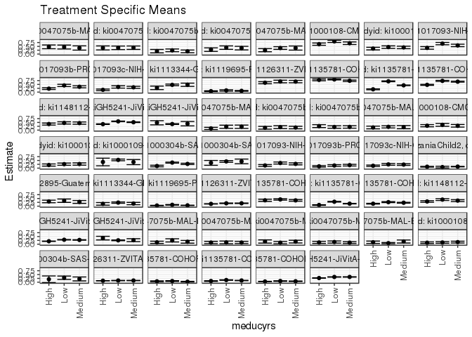

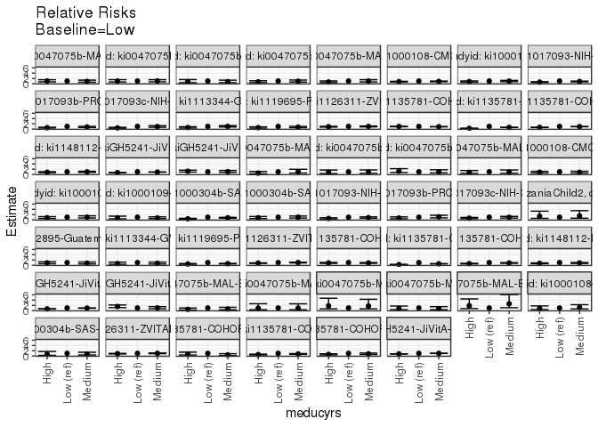

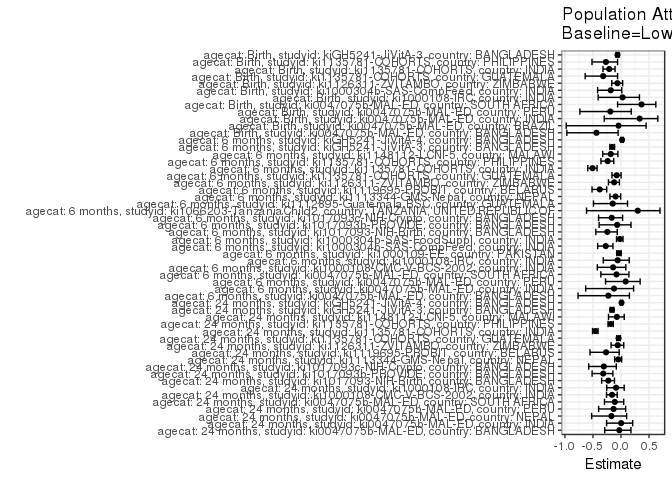

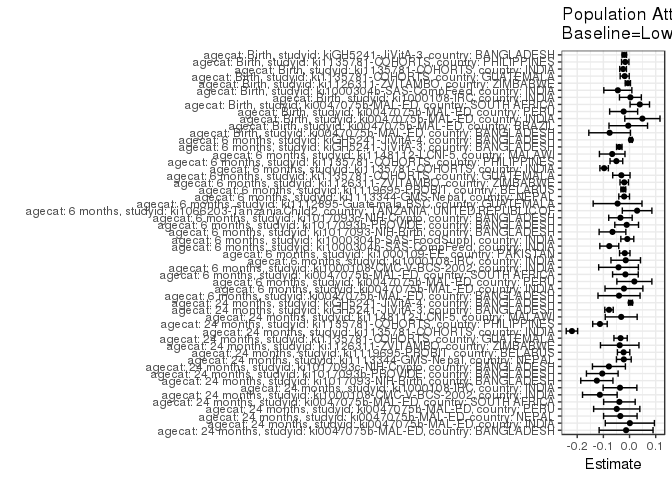

## Results Table

### Parameter: TSM

| agecat | studyid | country | intervention_level | baseline_level | estimate | ci_lower | ci_upper |
| --- | --- | --- | --- | --- | --- | --- | --- |
| Birth | ki0047075b-MAL-ED | BANGLADESH | Low | NA | 0.2500000 | 0.1468318 | 0.3531682 |
| Birth | ki0047075b-MAL-ED | BANGLADESH | Medium | NA | 0.1562500 | 0.0670784 | 0.2454216 |
| Birth | ki0047075b-MAL-ED | BANGLADESH | High | NA | 0.1200000 | 0.0462773 | 0.1937227 |
| Birth | ki0047075b-MAL-ED | BRAZIL | Low | NA | 0.1153846 | 0.0283196 | 0.2024496 |
| Birth | ki0047075b-MAL-ED | BRAZIL | Medium | NA | 0.1095890 | 0.0377416 | 0.1814365 |
| Birth | ki0047075b-MAL-ED | BRAZIL | High | NA | 0.1076923 | 0.0321332 | 0.1832514 |
| Birth | ki0047075b-MAL-ED | INDIA | Low | NA | 0.0983607 | 0.0234230 | 0.1732983 |
| Birth | ki0047075b-MAL-ED | INDIA | Medium | NA | 0.1690141 | 0.0816029 | 0.2564253 |
| Birth | ki0047075b-MAL-ED | INDIA | High | NA | 0.1764706 | 0.0715578 | 0.2813834 |
| Birth | ki0047075b-MAL-ED | PERU | Low | NA | 0.1414141 | 0.0726552 | 0.2101731 |
| Birth | ki0047075b-MAL-ED | PERU | Medium | NA | 0.1000000 | 0.0410980 | 0.1589020 |
| Birth | ki0047075b-MAL-ED | PERU | High | NA | 0.1149425 | 0.0478035 | 0.1820816 |
| Birth | ki0047075b-MAL-ED | SOUTH AFRICA | Low | NA | 0.0676692 | 0.0248998 | 0.1104386 |
| Birth | ki0047075b-MAL-ED | SOUTH AFRICA | Medium | NA | 0.1754386 | 0.0765115 | 0.2743657 |
| Birth | ki0047075b-MAL-ED | SOUTH AFRICA | High | NA | 0.1250000 | 0.0484630 | 0.2015370 |
| Birth | ki1000108-IRC | INDIA | Low | NA | 0.1126761 | 0.0606020 | 0.1647501 |
| Birth | ki1000108-IRC | INDIA | Medium | NA | 0.1353383 | 0.0771259 | 0.1935508 |
| Birth | ki1000108-IRC | INDIA | High | NA | 0.0973451 | 0.0426200 | 0.1520703 |
| Birth | ki1000304b-SAS-CompFeed | INDIA | Low | NA | 0.2906977 | 0.1800337 | 0.4013617 |
| Birth | ki1000304b-SAS-CompFeed | INDIA | Medium | NA | 0.2142857 | 0.0869223 | 0.3416491 |
| Birth | ki1000304b-SAS-CompFeed | INDIA | High | NA | 0.1935484 | -0.0222467 | 0.4093435 |
| Birth | ki1126311-ZVITAMBO | ZIMBABWE | Low | NA | 0.1101928 | 0.0988037 | 0.1215820 |
| Birth | ki1126311-ZVITAMBO | ZIMBABWE | Medium | NA | 0.1108511 | 0.1003274 | 0.1213749 |
| Birth | ki1126311-ZVITAMBO | ZIMBABWE | High | NA | 0.0979030 | 0.0911712 | 0.1046349 |
| Birth | ki1135781-COHORTS | GUATEMALA | Low | NA | 0.0767263 | 0.0503293 | 0.1031234 |
| Birth | ki1135781-COHORTS | GUATEMALA | Medium | NA | 0.0329670 | 0.0117744 | 0.0541597 |
| Birth | ki1135781-COHORTS | GUATEMALA | High | NA | 0.0561798 | 0.0223319 | 0.0900276 |
| Birth | ki1135781-COHORTS | INDIA | Low | NA | 0.1429385 | 0.1265663 | 0.1593107 |
| Birth | ki1135781-COHORTS | INDIA | Medium | NA | 0.1128684 | 0.1011089 | 0.1246280 |
| Birth | ki1135781-COHORTS | INDIA | High | NA | 0.0766962 | 0.0566637 | 0.0967286 |

[output cut: 132 more lines]

### Parameter: E(Y)

| agecat | studyid | country | intervention_level | baseline_level | estimate | ci_lower | ci_upper |
| --- | --- | --- | --- | --- | --- | --- | --- |
| Birth | ki0047075b-MAL-ED | BANGLADESH | NA | NA | 0.1739130 | 0.1221531 | 0.2256729 |
| Birth | ki0047075b-MAL-ED | BRAZIL | NA | NA | 0.1105263 | 0.0658254 | 0.1552272 |
| Birth | ki0047075b-MAL-ED | INDIA | NA | NA | 0.1475410 | 0.0960175 | 0.1990645 |
| Birth | ki0047075b-MAL-ED | PERU | NA | NA | 0.1188811 | 0.0813061 | 0.1564562 |
| Birth | ki0047075b-MAL-ED | SOUTH AFRICA | NA | NA | 0.1068702 | 0.0693890 | 0.1443514 |
| Birth | ki1000108-IRC | INDIA | NA | NA | 0.1159794 | 0.0840777 | 0.1478811 |
| Birth | ki1000304b-SAS-CompFeed | INDIA | NA | NA | 0.2459893 | 0.1594019 | 0.3325767 |
| Birth | ki1126311-ZVITAMBO | ZIMBABWE | NA | NA | 0.1036930 | 0.0986082 | 0.1087777 |
| Birth | ki1135781-COHORTS | GUATEMALA | NA | NA | 0.0581948 | 0.0423724 | 0.0740172 |
| Birth | ki1135781-COHORTS | INDIA | NA | NA | 0.1182899 | 0.1095248 | 0.1270550 |
| Birth | ki1135781-COHORTS | PHILIPPINES | NA | NA | 0.0613115 | 0.0527962 | 0.0698268 |
| Birth | kiGH5241-JiVitA-3 | BANGLADESH | NA | NA | 0.3232756 | 0.3156176 | 0.3309337 |
| 6 months | ki0047075b-MAL-ED | BANGLADESH | NA | NA | 0.1785714 | 0.1248161 | 0.2323268 |
| 6 months | ki0047075b-MAL-ED | INDIA | NA | NA | 0.1730769 | 0.1215404 | 0.2246134 |
| 6 months | ki0047075b-MAL-ED | PERU | NA | NA | 0.2205882 | 0.1712211 | 0.2699554 |
| 6 months | ki0047075b-MAL-ED | SOUTH AFRICA | NA | NA | 0.1968504 | 0.1478551 | 0.2458457 |
| 6 months | ki1000108-CMC-V-BCS-2002 | INDIA | NA | NA | 0.3008130 | 0.2539566 | 0.3476694 |
| 6 months | ki1000108-IRC | INDIA | NA | NA | 0.2457002 | 0.2038248 | 0.2875757 |
| 6 months | ki1000109-EE | PAKISTAN | NA | NA | 0.5176152 | 0.4665618 | 0.5686686 |
| 6 months | ki1000304b-SAS-CompFeed | INDIA | NA | NA | 0.2844311 | 0.2666491 | 0.3022132 |
| 6 months | ki1000304b-SAS-FoodSuppl | INDIA | NA | NA | 0.4289474 | 0.3791199 | 0.4787748 |
| 6 months | ki1017093-NIH-Birth | BANGLADESH | NA | NA | 0.2681564 | 0.2306532 | 0.3056597 |
| 6 months | ki1017093b-PROVIDE | BANGLADESH | NA | NA | 0.1612350 | 0.1313580 | 0.1911120 |
| 6 months | ki1017093c-NIH-Crypto | BANGLADESH | NA | NA | 0.2097902 | 0.1799252 | 0.2396552 |
| 6 months | ki1066203-TanzaniaChild2 | TANZANIA, UNITED REPUBLIC OF | NA | NA | 0.0964869 | 0.0836111 | 0.1093627 |
| 6 months | ki1112895-Guatemala BSC | GUATEMALA | NA | NA | 0.3104693 | 0.2558835 | 0.3650551 |
| 6 months | ki1113344-GMS-Nepal | NEPAL | NA | NA | 0.2125000 | 0.1785885 | 0.2464115 |
| 6 months | ki1119695-PROBIT | BELARUS | NA | NA | 0.0626864 | 0.0488489 | 0.0765239 |
| 6 months | ki1126311-ZVITAMBO | ZIMBABWE | NA | NA | 0.1665057 | 0.1584820 | 0.1745293 |
| 6 months | ki1135781-COHORTS | GUATEMALA | NA | NA | 0.4075630 | 0.3763327 | 0.4387933 |
| 6 months | ki1135781-COHORTS | INDIA | NA | NA | 0.1915758 | 0.1810911 | 0.2020606 |
| 6 months | ki1135781-COHORTS | PHILIPPINES | NA | NA | 0.2112260 | 0.1958496 | 0.2266024 |
| 6 months | ki1148112-LCNI-5 | MALAWI | NA | NA | 0.3628536 | 0.3297820 | 0.3959252 |
| 6 months | kiGH5241-JiVitA-3 | BANGLADESH | NA | NA | 0.2514589 | 0.2433251 | 0.2595926 |
| 6 months | kiGH5241-JiVitA-4 | BANGLADESH | NA | NA | 0.2573674 | 0.2348896 | 0.2798452 |
| 24 months | ki0047075b-MAL-ED | BANGLADESH | NA | NA | 0.4444444 | 0.3697487 | 0.5191402 |
| 24 months | ki0047075b-MAL-ED | INDIA | NA | NA | 0.4070352 | 0.3386053 | 0.4754651 |
| 24 months | ki0047075b-MAL-ED | NEPAL | NA | NA | 0.2065728 | 0.1520761 | 0.2610695 |
| 24 months | ki0047075b-MAL-ED | PERU | NA | NA | 0.3700000 | 0.3029201 | 0.4370799 |
| 24 months | ki0047075b-MAL-ED | SOUTH AFRICA | NA | NA | 0.3529412 | 0.2921001 | 0.4137823 |
| 24 months | ki1000108-CMC-V-BCS-2002 | INDIA | NA | NA | 0.7150538 | 0.6691221 | 0.7609854 |
| 24 months | ki1000108-IRC | INDIA | NA | NA | 0.4156479 | 0.3678270 | 0.4634689 |
| 24 months | ki1017093-NIH-Birth | BANGLADESH | NA | NA | 0.5547786 | 0.5076945 | 0.6018626 |
| 24 months | ki1017093b-PROVIDE | BANGLADESH | NA | NA | 0.3292894 | 0.2909105 | 0.3676684 |
| 24 months | ki1017093c-NIH-Crypto | BANGLADESH | NA | NA | 0.2568093 | 0.2190047 | 0.2946140 |
| 24 months | ki1113344-GMS-Nepal | NEPAL | NA | NA | 0.4495968 | 0.4057742 | 0.4934193 |
| 24 months | ki1119695-PROBIT | BELARUS | NA | NA | 0.0852540 | 0.0554439 | 0.1150642 |
| 24 months | ki1126311-ZVITAMBO | ZIMBABWE | NA | NA | 0.6520788 | 0.6083612 | 0.6957964 |
| 24 months | ki1135781-COHORTS | GUATEMALA | NA | NA | 0.7905660 | 0.7660589 | 0.8150732 |
| 24 months | ki1135781-COHORTS | INDIA | NA | NA | 0.4815520 | 0.4664409 | 0.4966632 |
| 24 months | ki1135781-COHORTS | PHILIPPINES | NA | NA | 0.6167689 | 0.5974942 | 0.6360437 |
| 24 months | ki1148112-LCNI-5 | MALAWI | NA | NA | 0.4370629 | 0.3963782 | 0.4777477 |
| 24 months | kiGH5241-JiVitA-3 | BANGLADESH | NA | NA | 0.4907783 | 0.4776560 | 0.5039007 |
| 24 months | kiGH5241-JiVitA-4 | BANGLADESH | NA | NA | 0.3988036 | 0.3729992 | 0.4246080 |

### Parameter: RR

| agecat | studyid | country | intervention_level | baseline_level | estimate | ci_lower | ci_upper |
| --- | --- | --- | --- | --- | --- | --- | --- |
| Birth | ki0047075b-MAL-ED | BANGLADESH | Low | Low | 1.0000000 | 1.0000000 | 1.0000000 |
| Birth | ki0047075b-MAL-ED | BANGLADESH | Medium | Low | 0.6250000 | 0.3090436 | 1.2639803 |
| Birth | ki0047075b-MAL-ED | BANGLADESH | High | Low | 0.4800000 | 0.2289943 | 1.0061384 |
| Birth | ki0047075b-MAL-ED | BRAZIL | Low | Low | 1.0000000 | 1.0000000 | 1.0000000 |
| Birth | ki0047075b-MAL-ED | BRAZIL | Medium | Low | 0.9497717 | 0.3495435 | 2.5806982 |
| Birth | ki0047075b-MAL-ED | BRAZIL | High | Low | 0.9333333 | 0.3330873 | 2.6152634 |
| Birth | ki0047075b-MAL-ED | INDIA | Low | Low | 1.0000000 | 1.0000000 | 1.0000000 |
| Birth | ki0047075b-MAL-ED | INDIA | Medium | Low | 1.7183098 | 0.6842146 | 4.3152961 |
| Birth | ki0047075b-MAL-ED | INDIA | High | Low | 1.7941176 | 0.6825905 | 4.7156498 |
| Birth | ki0047075b-MAL-ED | PERU | Low | Low | 1.0000000 | 1.0000000 | 1.0000000 |
| Birth | ki0047075b-MAL-ED | PERU | Medium | Low | 0.7071429 | 0.3294596 | 1.5177916 |
| Birth | ki0047075b-MAL-ED | PERU | High | Low | 0.8128079 | 0.3801234 | 1.7380055 |
| Birth | ki0047075b-MAL-ED | SOUTH AFRICA | Low | Low | 1.0000000 | 1.0000000 | 1.0000000 |
| Birth | ki0047075b-MAL-ED | SOUTH AFRICA | Medium | Low | 2.5925926 | 1.1114245 | 6.0476767 |
| Birth | ki0047075b-MAL-ED | SOUTH AFRICA | High | Low | 1.8472222 | 0.7662065 | 4.4534078 |
| Birth | ki1000108-IRC | INDIA | Low | Low | 1.0000000 | 1.0000000 | 1.0000000 |
| Birth | ki1000108-IRC | INDIA | Medium | Low | 1.2011278 | 0.6388507 | 2.2582869 |
| Birth | ki1000108-IRC | INDIA | High | Low | 0.8639381 | 0.4172739 | 1.7887267 |
| Birth | ki1000304b-SAS-CompFeed | INDIA | Low | Low | 1.0000000 | 1.0000000 | 1.0000000 |
| Birth | ki1000304b-SAS-CompFeed | INDIA | Medium | Low | 0.7371429 | 0.3826755 | 1.4199486 |
| Birth | ki1000304b-SAS-CompFeed | INDIA | High | Low | 0.6658065 | 0.2580765 | 1.7177010 |
| Birth | ki1126311-ZVITAMBO | ZIMBABWE | Low | Low | 1.0000000 | 1.0000000 | 1.0000000 |
| Birth | ki1126311-ZVITAMBO | ZIMBABWE | Medium | Low | 1.0059740 | 0.8742543 | 1.1575393 |
| Birth | ki1126311-ZVITAMBO | ZIMBABWE | High | Low | 0.8884700 | 0.7847474 | 1.0059021 |
| Birth | ki1135781-COHORTS | GUATEMALA | Low | Low | 1.0000000 | 1.0000000 | 1.0000000 |
| Birth | ki1135781-COHORTS | GUATEMALA | Medium | Low | 0.4296703 | 0.2072447 | 0.8908144 |
| Birth | ki1135781-COHORTS | GUATEMALA | High | Low | 0.7322097 | 0.3658655 | 1.4653777 |
| Birth | ki1135781-COHORTS | INDIA | Low | Low | 1.0000000 | 1.0000000 | 1.0000000 |
| Birth | ki1135781-COHORTS | INDIA | Medium | Low | 0.7896294 | 0.6763604 | 0.9218674 |
| Birth | ki1135781-COHORTS | INDIA | High | Low | 0.5365676 | 0.4034244 | 0.7136523 |

[output cut: 132 more lines]

### Parameter: PAR

| agecat | studyid | country | intervention_level | baseline_level | estimate | ci_lower | ci_upper |
| --- | --- | --- | --- | --- | --- | --- | --- |
| Birth | ki0047075b-MAL-ED | BANGLADESH | Low | NA | -0.0760870 | -0.1556471 | 0.0034732 |
| Birth | ki0047075b-MAL-ED | BRAZIL | Low | NA | -0.0048583 | -0.0785418 | 0.0688252 |
| Birth | ki0047075b-MAL-ED | INDIA | Low | NA | 0.0491803 | -0.0180994 | 0.1164600 |
| Birth | ki0047075b-MAL-ED | PERU | Low | NA | -0.0225330 | -0.0760736 | 0.0310075 |
| Birth | ki0047075b-MAL-ED | SOUTH AFRICA | Low | NA | 0.0392011 | 0.0020943 | 0.0763078 |
| Birth | ki1000108-IRC | INDIA | Low | NA | 0.0033033 | -0.0384647 | 0.0450714 |
| Birth | ki1000304b-SAS-CompFeed | INDIA | Low | NA | -0.0447084 | -0.0983169 | 0.0089002 |
| Birth | ki1126311-ZVITAMBO | ZIMBABWE | Low | NA | -0.0064999 | -0.0165505 | 0.0035507 |
| Birth | ki1135781-COHORTS | GUATEMALA | Low | NA | -0.0185316 | -0.0358521 | -0.0012110 |
| Birth | ki1135781-COHORTS | INDIA | Low | NA | -0.0246486 | -0.0374703 | -0.0118269 |
| Birth | ki1135781-COHORTS | PHILIPPINES | Low | NA | -0.0164663 | -0.0305385 | -0.0023941 |
| Birth | kiGH5241-JiVitA-3 | BANGLADESH | Low | NA | -0.0200193 | -0.0284421 | -0.0115964 |
| 6 months | ki0047075b-MAL-ED | BANGLADESH | Low | NA | -0.0401786 | -0.1205945 | 0.0402373 |
| 6 months | ki0047075b-MAL-ED | INDIA | Low | NA | -0.0213675 | -0.0937543 | 0.0510193 |
| 6 months | ki0047075b-MAL-ED | PERU | Low | NA | 0.0184606 | -0.0484720 | 0.0853932 |
| 6 months | ki0047075b-MAL-ED | SOUTH AFRICA | Low | NA | -0.0157480 | -0.0647433 | 0.0332472 |
| 6 months | ki1000108-CMC-V-BCS-2002 | INDIA | Low | NA | -0.0420441 | -0.1179190 | 0.0338307 |
| 6 months | ki1000108-IRC | INDIA | Low | NA | -0.0145737 | -0.0710400 | 0.0418925 |
| 6 months | ki1000109-EE | PAKISTAN | Low | NA | -0.0182104 | -0.0381700 | 0.0017493 |
| 6 months | ki1000304b-SAS-CompFeed | INDIA | Low | NA | -0.0773779 | -0.1135320 | -0.0412238 |
| 6 months | ki1000304b-SAS-FoodSuppl | INDIA | Low | NA | -0.0085526 | -0.0332915 | 0.0161862 |
| 6 months | ki1017093-NIH-Birth | BANGLADESH | Low | NA | -0.0651769 | -0.1162367 | -0.0141171 |
| 6 months | ki1017093b-PROVIDE | BANGLADESH | Low | NA | -0.0109872 | -0.0563567 | 0.0343823 |
| 6 months | ki1017093c-NIH-Crypto | BANGLADESH | Low | NA | -0.0347513 | -0.0795552 | 0.0100526 |
| 6 months | ki1066203-TanzaniaChild2 | TANZANIA, UNITED REPUBLIC OF | Low | NA | 0.0289193 | -0.0276344 | 0.0854731 |
| 6 months | ki1112895-Guatemala BSC | GUATEMALA | Low | NA | -0.0456951 | -0.1390067 | 0.0476165 |
| 6 months | ki1113344-GMS-Nepal | NEPAL | Low | NA | -0.0205827 | -0.0410095 | -0.0001559 |
| 6 months | ki1119695-PROBIT | BELARUS | Low | NA | -0.0237771 | -0.0329413 | -0.0146129 |
| 6 months | ki1126311-ZVITAMBO | ZIMBABWE | Low | NA | -0.0202308 | -0.0364449 | -0.0040167 |
| 6 months | ki1135781-COHORTS | GUATEMALA | Low | NA | -0.0311898 | -0.0642800 | 0.0019004 |
| 6 months | ki1135781-COHORTS | INDIA | Low | NA | -0.0971130 | -0.1133121 | -0.0809138 |
| 6 months | ki1135781-COHORTS | PHILIPPINES | Low | NA | -0.0502752 | -0.0744990 | -0.0260514 |
| 6 months | ki1148112-LCNI-5 | MALAWI | Low | NA | -0.0662651 | -0.1151107 | -0.0174196 |
| 6 months | kiGH5241-JiVitA-3 | BANGLADESH | Low | NA | -0.0391850 | -0.0495812 | -0.0287889 |
| 6 months | kiGH5241-JiVitA-4 | BANGLADESH | Low | NA | 0.0051294 | -0.0001392 | 0.0103980 |
| 24 months | ki0047075b-MAL-ED | BANGLADESH | Low | NA | -0.0131827 | -0.1162250 | 0.0898597 |
| 24 months | ki0047075b-MAL-ED | INDIA | Low | NA | 0.0012381 | -0.0926683 | 0.0951445 |
| 24 months | ki0047075b-MAL-ED | NEPAL | Low | NA | -0.0351855 | -0.0992279 | 0.0288569 |
| 24 months | ki0047075b-MAL-ED | PERU | Low | NA | -0.0489189 | -0.1372464 | 0.0394086 |
| 24 months | ki0047075b-MAL-ED | SOUTH AFRICA | Low | NA | -0.0387255 | -0.0990353 | 0.0215843 |
| 24 months | ki1000108-CMC-V-BCS-2002 | INDIA | Low | NA | -0.1135177 | -0.1796906 | -0.0473447 |
| 24 months | ki1000108-IRC | INDIA | Low | NA | -0.0364069 | -0.1008723 | 0.0280585 |
| 24 months | ki1017093-NIH-Birth | BANGLADESH | Low | NA | -0.1249600 | -0.1865041 | -0.0634159 |
| 24 months | ki1017093b-PROVIDE | BANGLADESH | Low | NA | -0.1042366 | -0.1647335 | -0.0437397 |
| 24 months | ki1017093c-NIH-Crypto | BANGLADESH | Low | NA | -0.0788071 | -0.1417997 | -0.0158145 |
| 24 months | ki1113344-GMS-Nepal | NEPAL | Low | NA | -0.0218318 | -0.0499972 | 0.0063336 |
| 24 months | ki1119695-PROBIT | BELARUS | Low | NA | -0.0227005 | -0.0463340 | 0.0009329 |
| 24 months | ki1126311-ZVITAMBO | ZIMBABWE | Low | NA | -0.0375764 | -0.1111191 | 0.0359663 |
| 24 months | ki1135781-COHORTS | GUATEMALA | Low | NA | -0.0342371 | -0.0596537 | -0.0088206 |
| 24 months | ki1135781-COHORTS | INDIA | Low | NA | -0.2201748 | -0.2420091 | -0.1983405 |
| 24 months | ki1135781-COHORTS | PHILIPPINES | Low | NA | -0.1130698 | -0.1408215 | -0.0853180 |
| 24 months | ki1148112-LCNI-5 | MALAWI | Low | NA | -0.0318636 | -0.0928451 | 0.0291179 |
| 24 months | kiGH5241-JiVitA-3 | BANGLADESH | Low | NA | -0.0784627 | -0.0945596 | -0.0623658 |
| 24 months | kiGH5241-JiVitA-4 | BANGLADESH | Low | NA | 0.0038546 | -0.0034851 | 0.0111944 |

### Parameter: PAF

| agecat | studyid | country | intervention_level | baseline_level | estimate | ci_lower | ci_upper |
| --- | --- | --- | --- | --- | --- | --- | --- |
| Birth | ki0047075b-MAL-ED | BANGLADESH | Low | NA | -0.4375000 | -0.9660300 | -0.0510553 |
| Birth | ki0047075b-MAL-ED | BRAZIL | Low | NA | -0.0439560 | -0.9767217 | 0.4486608 |
| Birth | ki0047075b-MAL-ED | INDIA | Low | NA | 0.3333333 | -0.2984635 | 0.6577151 |
| Birth | ki0047075b-MAL-ED | PERU | Low | NA | -0.1895425 | -0.7330719 | 0.1835242 |
| Birth | ki0047075b-MAL-ED | SOUTH AFRICA | Low | NA | 0.3668099 | -0.0601895 | 0.6218320 |
| Birth | ki1000108-IRC | INDIA | Low | NA | 0.0284820 | -0.4073809 | 0.3293591 |
| Birth | ki1000304b-SAS-CompFeed | INDIA | Low | NA | -0.1817492 | -0.4167921 | 0.0143005 |
| Birth | ki1126311-ZVITAMBO | ZIMBABWE | Low | NA | -0.0626837 | -0.1641277 | 0.0299203 |
| Birth | ki1135781-COHORTS | GUATEMALA | Low | NA | -0.3184404 | -0.6389444 | -0.0606127 |
| Birth | ki1135781-COHORTS | INDIA | Low | NA | -0.2083747 | -0.3209615 | -0.1053838 |
| Birth | ki1135781-COHORTS | PHILIPPINES | Low | NA | -0.2685680 | -0.5171177 | -0.0607383 |
| Birth | kiGH5241-JiVitA-3 | BANGLADESH | Low | NA | -0.0619263 | -0.0883582 | -0.0361365 |
| 6 months | ki0047075b-MAL-ED | BANGLADESH | Low | NA | -0.2250000 | -0.7658070 | 0.1501761 |
| 6 months | ki0047075b-MAL-ED | INDIA | Low | NA | -0.1234568 | -0.6289288 | 0.2251625 |
| 6 months | ki0047075b-MAL-ED | PERU | Low | NA | 0.0836879 | -0.2756273 | 0.3417923 |
| 6 months | ki0047075b-MAL-ED | SOUTH AFRICA | Low | NA | -0.0800000 | -0.3594402 | 0.1419998 |
| 6 months | ki1000108-CMC-V-BCS-2002 | INDIA | Low | NA | -0.1397683 | -0.4220661 | 0.0864898 |
| 6 months | ki1000108-IRC | INDIA | Low | NA | -0.0593151 | -0.3158816 | 0.1472269 |
| 6 months | ki1000109-EE | PAKISTAN | Low | NA | -0.0351813 | -0.0746668 | 0.0028535 |
| 6 months | ki1000304b-SAS-CompFeed | INDIA | Low | NA | -0.2720444 | -0.4156339 | -0.1430194 |
| 6 months | ki1000304b-SAS-FoodSuppl | INDIA | Low | NA | -0.0199387 | -0.0793000 | 0.0361578 |
| 6 months | ki1017093-NIH-Birth | BANGLADESH | Low | NA | -0.2430556 | -0.4485084 | -0.0667436 |
| 6 months | ki1017093b-PROVIDE | BANGLADESH | Low | NA | -0.0681442 | -0.3898588 | 0.1791022 |
| 6 months | ki1017093c-NIH-Crypto | BANGLADESH | Low | NA | -0.1656477 | -0.3994326 | 0.0290818 |
| 6 months | ki1066203-TanzaniaChild2 | TANZANIA, UNITED REPUBLIC OF | Low | NA | 0.2997228 | -0.6145519 | 0.6962698 |
| 6 months | ki1112895-Guatemala BSC | GUATEMALA | Low | NA | -0.1471806 | -0.4908250 | 0.1172516 |
| 6 months | ki1113344-GMS-Nepal | NEPAL | Low | NA | -0.0968598 | -0.1967690 | -0.0052913 |
| 6 months | ki1119695-PROBIT | BELARUS | Low | NA | -0.3793029 | -0.5164529 | -0.2545568 |
| 6 months | ki1126311-ZVITAMBO | ZIMBABWE | Low | NA | -0.1215022 | -0.2231277 | -0.0283203 |
| 6 months | ki1135781-COHORTS | GUATEMALA | Low | NA | -0.0765274 | -0.1609677 | 0.0017713 |
| 6 months | ki1135781-COHORTS | INDIA | Low | NA | -0.5069166 | -0.5925055 | -0.4259276 |
| 6 months | ki1135781-COHORTS | PHILIPPINES | Low | NA | -0.2380162 | -0.3576931 | -0.1288885 |
| 6 months | ki1148112-LCNI-5 | MALAWI | Low | NA | -0.1826222 | -0.3255976 | -0.0550678 |
| 6 months | kiGH5241-JiVitA-3 | BANGLADESH | Low | NA | -0.1558308 | -0.1981847 | -0.1149741 |
| 6 months | kiGH5241-JiVitA-4 | BANGLADESH | Low | NA | 0.0199301 | -0.0008833 | 0.0403108 |
| 24 months | ki0047075b-MAL-ED | BANGLADESH | Low | NA | -0.0296610 | -0.2897262 | 0.1779636 |
| 24 months | ki0047075b-MAL-ED | INDIA | Low | NA | 0.0030417 | -0.2565453 | 0.2090011 |
| 24 months | ki0047075b-MAL-ED | NEPAL | Low | NA | -0.1703297 | -0.5236352 | 0.1010502 |
| 24 months | ki0047075b-MAL-ED | PERU | Low | NA | -0.1322133 | -0.3984592 | 0.0833434 |
| 24 months | ki0047075b-MAL-ED | SOUTH AFRICA | Low | NA | -0.1097222 | -0.2947152 | 0.0488384 |
| 24 months | ki1000108-CMC-V-BCS-2002 | INDIA | Low | NA | -0.1587540 | -0.2579847 | -0.0673507 |
| 24 months | ki1000108-IRC | INDIA | Low | NA | -0.0875907 | -0.2544971 | 0.0571095 |
| 24 months | ki1017093-NIH-Birth | BANGLADESH | Low | NA | -0.2252430 | -0.3450077 | -0.1161427 |
| 24 months | ki1017093b-PROVIDE | BANGLADESH | Low | NA | -0.3165500 | -0.5149496 | -0.1441331 |
| 24 months | ki1017093c-NIH-Crypto | BANGLADESH | Low | NA | -0.3068701 | -0.5762029 | -0.0835594 |
| 24 months | ki1113344-GMS-Nepal | NEPAL | Low | NA | -0.0485586 | -0.1132489 | 0.0123726 |
| 24 months | ki1119695-PROBIT | BELARUS | Low | NA | -0.2662692 | -0.5531135 | -0.0324021 |
| 24 months | ki1126311-ZVITAMBO | ZIMBABWE | Low | NA | -0.0576255 | -0.1768584 | 0.0495273 |
| 24 months | ki1135781-COHORTS | GUATEMALA | Low | NA | -0.0433071 | -0.0761556 | -0.0114612 |
| 24 months | ki1135781-COHORTS | INDIA | Low | NA | -0.4572192 | -0.5071183 | -0.4089723 |
| 24 months | ki1135781-COHORTS | PHILIPPINES | Low | NA | -0.1833260 | -0.2302406 | -0.1382005 |
| 24 months | ki1148112-LCNI-5 | MALAWI | Low | NA | -0.0729040 | -0.2220334 | 0.0580267 |
| 24 months | kiGH5241-JiVitA-3 | BANGLADESH | Low | NA | -0.1598740 | -0.1937837 | -0.1269275 |
| 24 months | kiGH5241-JiVitA-4 | BANGLADESH | Low | NA | 0.0096655 | -0.0089075 | 0.0278966 |